# Session 3: Reproducible analysis practices

# 1 Introduction

If you have ever worked on a project, or collaborated with other team members, then you have already created different versions of your document to update it.

This is a primitive way of the version control because it’s manual and not detailed. If we want to figure out the differences between 2 copies just by putting them side-by-side, it will be very time-consuming and super error-prone.

In this session, you’ll be introduced to the concept of version control system (VCS) to maintain a detailed history of the created versions. By using a VCS, we can know when the changes were made and who made them.

We’ll be using one of the most popular version control system called [Git](https://git-scm.com/) and show you some of the ways you can use it.

We’ll also learn how to set up an account with the service called [GitHub](https://github.com/), so that you can create your own remote repositories to store your code and data.

# 2 Git Overview

A version control tracks the changes that happen within directories or files. There are two main types of version control systems:

- The centralized model: all users connect to a central, master repository.
- The distributed model: each user has a copy of entire repository on their computer and these repositroies can easily be synchronized.

Git is distributed VCS, free and open source tool.

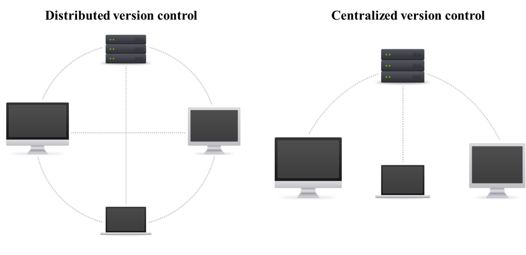

## 2.1 Installation and getting start with Git

Check if your computer has a Git installed by typing the following command line:

```
osboxes@osboxes:~$ git --version
```

If no version information is shown, you need to install it yourself

```
osboxes@osboxes:~$ sudo apt-get update
osboxes@osboxes:~$ sudo apt-get install git
```

We have already said that by using VCS we can know which user have made the changes. For this, we need to tell git our identity using the following command lines:

```
osboxes@osboxes:~$ git config --global user.name "my_name"
osboxes@osboxes:~$ git config --global user.email "name@example.com"
```

### 2.1.1 Setting up a new Git repository

A Git repository (repo) is a directory that contains your project work. It allows you to save versions of your code, which you can access when needed.

To create a new repo, you’ll use the `git init` command. Executing this command will create a new .git subdirectory in your current working directory

```
osboxes@osboxes:~$ mkdir my_project
osboxes@osboxes:~$ cd my_project
osboxes@osboxes:~$ get init
osboxes@osboxes:~$ ls -la #check for the hidden directories
osboxes@osboxes:~$ ls -l  # check the files inside the .git subdirecotry
```

### 2.1.2 Clone an existing Repository

To get an identical copy of an existing repository: for example, a project that you would like to contribute to. The command you need to create a local copy on your computer is `git clone`

```
osboxes@osboxes:~$ git clone https://github.com/eead-csic-compbio/bioinformatics.git
```